# **SEARCHING**

### **Pencarian Linier**

Pencarian linear (atau pencarian sekuensial) adalah algoritma pencarian paling sederhana. Algoritma ini memeriksa setiap elemen satu per satu.

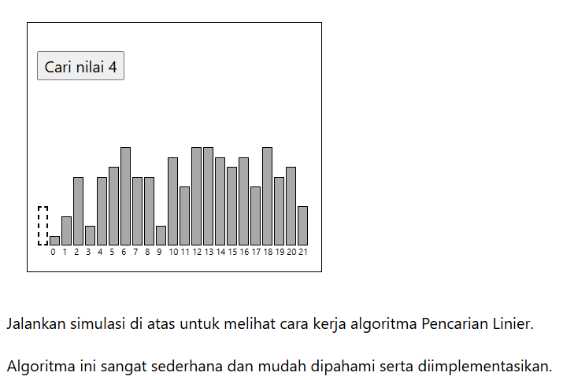

## 1. Linear Search (Pencarian Sekuensial)

```python
# Implementasi Linear Search dari slide [cite: 16]
search = 2
myList = [1, 2, 3, 4, 5, 6]
position = len(myList) - 1
last = 0
found = False

# Looping mundur dari indeks paling belakang
while position >= last and not found:
    if myList[position] == search:
        found = True
    else:
        position = position - 1

if found:
    print("Found the search number.")
    print(position)
else:
    print("Did not find the search number.")
```

**Cara kerjanya:**

1. Telusuri array nilai demi nilai dari awal.
2. Bandingkan setiap nilai untuk memeriksa apakah nilainya sama dengan nilai yang kita cari.
3. Jika nilai tersebut ditemukan, kembalikan indeks dari nilai tersebut.
4. Jika akhir array tercapai dan nilai tidak ditemukan, kembalikan -1 untuk menunjukkan bahwa nilai tersebut tidak ditemukan.

(Jika array sudah diurutkan, lebih baik menggunakan algoritma Pencarian Biner yang jauh lebih cepat yang akan kita bahas di halaman berikutnya.)

### **Menerapkan Pencarian Linier di Python**

**Contoh**

Periksa apakah suatu nilai ada dalam sebuah daftar:

```python
mylist = [3, 7, 2, 9, 5, 1, 8, 4, 6]

if 4 in mylist:
  print("Found!")
else:
  print("Not found!")
```

Namun jika Anda perlu menemukan indeks suatu nilai, Anda perlu menerapkan pencarian linier:

**Contoh**

Temukan indeks suatu nilai dalam sebuah daftar:

```python
def linearSearch(arr, targetVal):
  for i in range(len(arr)):
    if arr[i] == targetVal:
      return i
  return -1

mylist = [3, 7, 2, 9, 5, 1, 8, 4, 6]
x = 4

result = linearSearch(mylist, x)

if result != -1:
  print("Found at index", result)
else:
  print("Not found")
```

Untuk mengimplementasikan algoritma Pencarian Linier, kita membutuhkan:

1. Sebuah array berisi nilai-nilai yang akan dicari.
2. Nilai target yang akan dicari.
3. Sebuah perulangan yang menelusuri array dari awal hingga akhir.
4. Sebuah pernyataan if yang membandingkan nilai saat ini dengan nilai target, dan mengembalikan indeks saat ini jika nilai target ditemukan.
5. Setelah perulangan, kembalikan -1, karena pada titik ini kita tahu nilai target belum ditemukan.

# **Kompleksitas Waktu Pencarian Linier**

Jika Pencarian Linier berjalan dan menemukan nilai target sebagai nilai array pertama dalam sebuah array dengan N untuk nilai-nilai tersebut, hanya diperlukan satu perbandingan.

Namun jika Pencarian Linier dijalankan melalui seluruh array N nilai, tanpa menemukan nilai target, N Perbandingan diperlukan.

## **Algoritma Pencarian**

Algoritma pencarian adalah teknik fundamental yang digunakan untuk menemukan elemen atau nilai dalam kumpulan data. Dalam tutorial ini, kita akan menjelajahi beberapa algoritma pencarian yang paling umum digunakan di Python. Algoritma-algoritma ini meliputi Pencarian Linier, Pencarian Biner, Pencarian Interpolasi, dan Pencarian Lompatan.

## **1. Pencarian Linier**

Pencarian linear adalah algoritma pencarian paling sederhana. Algoritma ini secara berurutan memeriksa setiap elemen dalam daftar hingga menemukan nilai yang dicari.

**Tangga:**

- Mulailah dari elemen pertama dalam daftar.
- Bandingkan setiap elemen dalam daftar dengan nilai target.
- Jika elemen tersebut cocok dengan nilai target, kembalikan indeksnya.
- Jika nilai target tidak ditemukan setelah mengulangi seluruh daftar, kembalikan -1.

**Implementasi Pencarian Linier di Python:**

```python
def linear_search(arr, target):
    """
    Perform linear search to find the target value in the given list.

    Parameters:
        arr (list): The list to be searched.
        target: The value to be searched for.

    Returns:
        int: The index of the target value if found, otherwise -1.
    """
    for i in range(len(arr)):
        if arr[i] == target:
            return i
    return -1

# Example usage:
arr = [2, 3, 4, 10, 40]
target = 10
result = linear_search(arr, target)
if result != -1:
    print(f"Linear Search: Element found at index {result}")
else:
    print("Linear Search: Element not found")
```

Pencarian data terkadang sangat diperlukan pada proses komputasi, sistem informasi, dan lain- lain. Dengan pencarian data ini maka data yang diperlukan dapat diketahui posisinya terhadap kumpulan data yang lain, sehingga data ini dapat digunakan untuk proses berikutnya. Misalkan pada data mahasiswa, diperlukan data lengkap tentang mahasiswa dengan Nomor induk XXXXXX, maka diperlukan proses pencarian data tersebut dengan key berupa nomor induk mahasiswa. Data yang didapat ini dapat digunakan untuk keperluan yang lain, misalkan keperluan administratif.

Pada umumnya, proses pencarian data ini menghasilkan posisi data yang dicari terhadap keseluruhan data, akan tetapi untuk pencarian data yang sederhana, nilai True atau False saja yang dihasilkan, nilai ini menandakan apakah data berada di sekumpulan data ataukah tidak. Proses pencarian sederhana ini sudah disediakan oleh python dengan menggunakan syntax in, seperti contoh berikut:

```python
a=[12,5,9,8,1,10,26]
11 in a

12 in a

15 in a
```

Algoritma searching yang pertama adalah sequential search.

**Sequential Search** merupakan teknik pencarian data dengan cara membandingkan data yang dicari dengan seluruh data yang terdapat pada kumpulan data secara satu persatu, mulai dari data pertama sampai dengan data terakhir. Ilustrasi sequential search ini dapat dilihat pada Gambar 1 berikut.

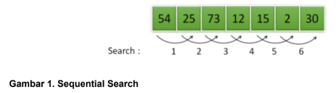

Terdapat dua konsep untuk sequential search berdasarkan kumpulan data yang akan dicari, yaitu

1. Unordered List Sequential Search
2. Ordered List Sequential Search

## **Unordered List Sequential Search**

Pada unordered list sequential search, data berada pada keadaan acak, tidak terurut, sehingga pencarian harus dilakukan mulai dari indeks awal sampai indeks terakhir dari data, atau pencarian berhenti ketika data sudah ditemukan.

**Code**

Berikut implementasi algoritma unordered list sequential search.

```python
def seqSearch(listData, data):
    ind = 0
    found = False
    while ind < len(listData) and not found:
        if listData[ind] == data:
            found = True
        else:
            ind = ind+1
    return found

a=[12,5,9,8,1,10,26]
seqSearch(a,1)
```

## **Ordered List Sequential Search**

Pada ordered list sequential search, data sudah dalam keadaan terurut, hal ini tentunya dapat mengurangi waktu komputasi pencarian. Ilustrasi algoritma pencarian ini, dapat dilihat pada Gambar 2 berikut:

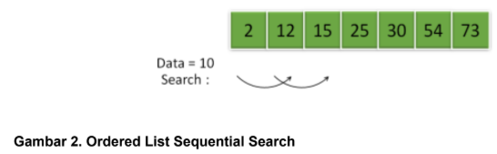

Misalkan data yang dicari adalah 10, pada index kedua dari data tersebut adalah 15, oleh karena itu dapat disimpulkan bahwa data 10 tidak terdapat pada list. karena indeks kedua sampai indeks terakhir memiliki nilai lebih besar dari 15. Sehingga data yang sudah dalam keadaan terurut dapat mempercepat waktu komputasi.

Berikut implementasi algoritma sequential search pada ordered list

```python
def orderedSeqSearch(listData, data):
    ind = 0
    found = False
    stop = False
    position=[]
    while ind < len(listData) and not found and not stop:
        if listData[ind] == data:
            found = True
            position.append(ind)
        else:
            if listData[ind] > data:
                stop = True
            else:
                ind = ind+1


    if found:
        return ind
    else:
        return ('Data tidak ada')

a=[1,1,5,5,5,8,9,10,12,26]
ind=orderedSeqSearch(a,5)
print(ind)
```

## **2. Pencarian Biner**

Pencarian biner adalah algoritma pencarian yang lebih efisien dan cocok untuk daftar yang sudah diurutkan. Algoritma ini berulang kali membagi interval pencarian menjadi dua hingga nilai target ditemukan.

**Tangga:**

1. Mulailah dengan seluruh daftar yang sudah diurutkan.
2. Hitung elemen tengah dari daftar tersebut.
3. Jika elemen tengah sama dengan nilai target, kembalikan indeksnya.
4. Jika elemen tengah kurang dari nilai target, cari di bagian kanan daftar.
5. Jika elemen tengah lebih besar dari nilai target, cari di bagian kiri daftar.
6. Ulangi langkah 2-5 hingga nilai target ditemukan atau interval pencarian kosong.

**Implementasi Pencarian Biner di Python (Rekursif):**

```python
def binary_search(arr, target, low, high):
    """
    Perform binary search recursively to find the target value in the given sorted list.

    Parameters:
        arr (list): The sorted list to be searched.
        target: The value to be searched for.
        low (int): The lower index of the search interval.
        high (int): The upper index of the search interval.

    Returns:
        int: The index of the target value if found, otherwise -1.
    """
    if low <= high:
        mid = (low + high) // 2
        if arr[mid] == target:
            return mid
        elif arr[mid] < target:
            return binary_search(arr, target, mid + 1, high)
        else:
            return binary_search(arr, target, low, mid - 1)
    else:
        return -1

# Example usage:
arr = [2, 3, 4, 10, 40]
target = 10
result = binary_search(sorted(arr), target, 0, len(arr) - 1)
if result != -1:
    print(f"Binary Search: Element found at index {result}")
else:
    print("Binary Search: Element not found")
```

Algoritma Pencarian Biner mencari melalui array yang sudah diurutkan dan mengembalikan indeks dari nilai yang dicari.

Pencarian Biner jauh lebih cepat daripada Pencarian Linier, tetapi membutuhkan array yang sudah diurutkan agar dapat berfungsi.

Algoritma Pencarian Biner bekerja dengan memeriksa nilai di tengah array. Jika nilai target lebih rendah, nilai berikutnya yang akan diperiksa berada di tengah bagian kiri array. Cara pencarian ini berarti bahwa area pencarian selalu setengah dari area pencarian sebelumnya, dan inilah mengapa algoritma Pencarian Biner sangat cepat.

Proses pengurangan separuh area pencarian ini terjadi hingga nilai target ditemukan, atau hingga area pencarian pada array kosong.

**Cara kerjanya:**

Periksa nilai di tengah array. Jika nilai target lebih rendah, cari di separuh kiri array. Jika nilai target lebih tinggi, cari di separuh kanan. Lanjutkan langkah 1 dan 2 untuk bagian array yang telah diperkecil hingga nilai target ditemukan atau hingga area pencarian kosong. Jika nilai ditemukan, kembalikan indeks nilai target. Jika nilai target tidak ditemukan, kembalikan -1.

## Panduan Langkah demi Langkah

Mari kita coba melakukan pencarian secara manual, hanya untuk mendapatkan pemahaman yang lebih baik tentang cara kerja Pencarian Biner sebelum benar-benar mengimplementasikannya dalam program Python. Kita akan mencari nilai 11.

**Langkah 1:** Kita mulai dengan sebuah array.

[ 2, 3, 7, 7, 11, 15, 25]

**Langkah 2:** Apakah nilai di tengah array pada indeks 3 sama dengan 11?

[ 2, 3, 7, 7, 11, 15, 25]

**Langkah 3:** 7 kurang dari 11, jadi kita harus mencari 11 di sebelah kanan indeks 3. Nilai-nilai di sebelah kanan indeks 3 adalah [11, 15, 25]. Nilai berikutnya yang perlu diperiksa adalah nilai tengah yaitu 15, pada indeks 5.

[ 2, 3, 7, 7, 11, 15, 25]

**Langkah 4:** 15 lebih tinggi dari 11, jadi kita harus mencari di sebelah kiri indeks 5. Kita sudah memeriksa indeks 0-3, jadi indeks 4 adalah satu-satunya nilai yang tersisa untuk diperiksa.

[ 2, 3, 7, 7, 11, 15, 25]

Kami telah menemukannya!

Nilai 11 ditemukan pada indeks 4.

Mengembalikan posisi indeks 4.

Pencarian Biner telah selesai.

## Mengimplementasikan Pencarian Biner di Python

Untuk mengimplementasikan algoritma Pencarian Biner, kita membutuhkan:

1. Sebuah array berisi nilai-nilai yang akan dicari.
2. Nilai target yang akan dicari.
3. Sebuah perulangan yang berjalan selama indeks kiri kurang dari atau sama dengan indeks kanan.
4. Sebuah pernyataan if yang membandingkan nilai tengah dengan nilai target, dan mengembalikan indeks jika nilai target ditemukan.
5. Sebuah pernyataan if yang memeriksa apakah nilai target kurang dari, atau lebih besar dari, nilai tengah, dan memperbarui variabel "kiri" atau "kanan" untuk mempersempit area pencarian.
6. Setelah perulangan, kembalikan -1, karena pada titik ini kita tahu nilai target belum ditemukan. Kode yang dihasilkan untuk Pencarian Biner akan terlihat seperti ini:

### Contoh

Buat algoritma Pencarian Biner di Python:

```python
def binarySearch(arr, targetVal):
  left = 0
  right = len(arr) - 1

  while left <= right:
    mid = (left + right) // 2

    if arr[mid] == targetVal:
      return mid

    if arr[mid] < targetVal:
      left = mid + 1
    else:
      right = mid - 1

  return -1

mylist = [1, 3, 5, 7, 9, 11, 13, 15, 17, 19]
x = 11

result = binarySearch(mylist, x)

if result != -1:
  print("Found at index", result)
else:
  print("Not found")
```

## Kompleksitas Waktu Pencarian Biner

Setiap kali Pencarian Biner memeriksa nilai baru untuk melihat apakah nilai tersebut adalah nilai target, area pencarian akan dibagi dua.

Jika kita menggambarkan berapa banyak waktu yang dibutuhkan Pencarian Biner untuk menemukan suatu nilai dalam sebuah array N Jika dibandingkan dengan Pencarian Linier, kita mendapatkan grafik berikut:

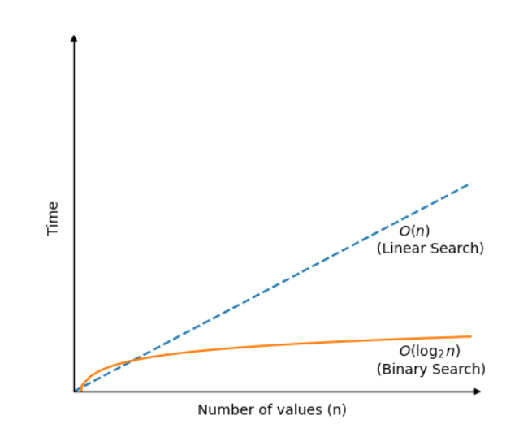

## **3. Pencarian Interpolasi**

Pencarian interpolasi adalah versi yang lebih baik dari pencarian biner, terutama cocok untuk array besar dan terdistribusi secara seragam. Pencarian ini menghitung posisi yang mungkin dari nilai target berdasarkan nilai kunci dan rentang ruang pencarian.

**Tangga:**

1. Hitung posisi probabilitas nilai target menggunakan rumus interpolasi.
2. Bandingkan nilai target dengan elemen pada posisi yang dihitung.
3. Jika elemen tersebut cocok dengan nilai target, kembalikan indeksnya.
4. Jika elemen tersebut kurang dari nilai target, cari di bagian kanan daftar.
5. Jika elemen tersebut lebih besar dari nilai target, cari di bagian kiri daftar.
6. Ulangi langkah 1-5 hingga nilai target ditemukan atau interval pencarian kosong. Implementasi Pencarian Interpolasi di Python:

```python
import math

def interpolation_search(arr, target):
    """
    Perform interpolation search to find the target value in the given sorted list.

    Parameters:
        arr (list): The sorted list to be searched.
        target: The value to be searched for.

    Returns:
        int: The index of the target value if found, otherwise -1.
    """
    low = 0
    high = len(arr) - 1
    while low <= high and target >= arr[low] and target <= arr[high]:
        pos = low + ((high - low) // (arr[high] - arr[low])) * (target - arr[low])
        if arr[pos] == target:
            return pos
        elif arr[pos] < target:
            low = pos + 1
        else:
            high = pos - 1
    return -1

# Example usage:
arr = [2, 3, 4, 10, 40]
target = 10
result = interpolation_search(sorted(arr), target)
if result != -1:
    print(f"Interpolation Search: Element found at index {result}")
else:
    print("Interpolation Search: Element not found")
```

## **4. Pencarian Lompat**

Jump search adalah algoritma pencarian lain yang cocok untuk array yang sudah diurutkan. Algoritma ini melompat maju dengan sejumlah langkah tetap dan kemudian melakukan pencarian linear dalam rentang yang lebih kecil.

**Tangga:**

1. Tentukan ukuran blok untuk melompat ke depan.
2. Lompat maju sebesar ukuran blok hingga nilai target lebih besar dari elemen terakhir blok saat ini.
3. Lakukan pencarian linear di dalam blok saat ini untuk menemukan nilai target.
4. Jika nilai target ditemukan, kembalikan indeksnya.
5. Jika nilai target tidak ditemukan setelah mengulangi semua blok, kembalikan -1.

**Implementasi Pencarian Lompatan (Jump Search) di Python:**

```python
import math

def jump_search(arr, target):
    """
    Perform jump search to find the target value in the given sorted list.

    Parameters:
        arr (list): The sorted list to be searched.
        target: The value to be searched for.

    Returns:
        int: The index of the target value if found, otherwise -1.
    """
    n = len(arr)
    step = int(math.sqrt(n))
    prev = 0
    while arr[min(step, n) - 1] < target:
        prev = step
        step += int(math.sqrt(n))
        if prev >= n:
            return -1
    while arr[prev] < target:
        prev += 1
        if prev == min(step, n):
            return -1
    if arr[prev] == target:
        return prev
    return -1

# Example usage:
arr = [2, 3, 4, 10, 40]
target = 10
result = jump_search(sorted(arr), target)
if result != -1:
    print(f"Jump Search: Element found at index {result}")
else:
    print("Jump Search: Element not found")
```